# The impact of groundwater temperature on the composition of groundwater microbial communities in an urban aquifer

Angela Cukusic

# 1 Load packages

```r
library(tidyverse)
library(stringr)
library(broom)
library(rstatix)      # tidyverse-compatible statistical testing
library(ggpmisc)      # adding equation on ggplots
library(vegan)
library(patchwork)    # combining plots in a single figure
library(ggpubr)       # cleaner plotting and for stat_corr
library(MASS)
library(ggfortify)
library(ggrepel)
library(knitr)


# coordianate plotting
library(mapview)
library(sf)
library(geosphere)



# Set the ggplot theme
theme_set(theme_linedraw())
```

# 2 Load data

The data has been prepared for analysis with four scripts in the same repository (https://github.com/angela34a/HBTC_micro/tree/main/Data%20cleaning).

The metadata has been cleaned of unnecessary variables, as well as combined together from both the spring and fall sampling campain. It has, furthermore, been decontaminated by the *decontam* package, the contaminants and blanks were then removed from the count table, replicates of the same sampling site were summed up, and, finally, the temperature categorization has been added as a variable.

The final count table and taxonomy table (no contaminat ASVs and no blank samples) and clean metadata info is loaded in this chunk.

```r
# a) final metadata
metadata <- read.csv("C:/Users/Angela Cukusic/Desktop/DS_analysis/data/clean_data/master_data.csv") %>%
  dplyr::select(-"X.1") %>%
# filter out the surface water
  dplyr::filter(Type != "SW")


# b) final asv_table
asv_table <-read.csv("C:/Users/Angela Cukusic/Desktop/DS_analysis/data/clean_data/asv_table_final.csv",
                     check.names = FALSE, row.names = 1)
# filter out the surface water again
asv_table <- asv_table[, colnames(asv_table) %in% metadata$sample_season]


# c) final taxonomy table
tax_table <- read.csv("C:/Users/Angela Cukusic/Desktop/DS_analysis/data/clean_data/tax_no_cont.csv",  row.names = 1)


# d) additional data on heat islands
spring_data_additional <- read.csv("C:/Users/Angela Cukusic/Desktop/DS_analysis/data/clean_data/spring_data_additional.csv",
         check.names = FALSE)
# add ifentifier column
spring_data_additional$sample_season <- paste(spring_data_additional$Sample_ID,
                                              "spring", sep = "_")
# remove indexed row names
spring_data_additional <- spring_data_additional[,-1]
```

The palettes for the temperature categories color scheme (blue to red; cold to warm) and composition (25 colors distinct from one another to differentiate between taxa abundances).

```r
# color palettes
pal3 = c("#253494", "#225ea8", "#1d91c0", "#7fcdbb" ,
         "#fdbb84", "#d7301f", "#7f0000", "gray")

c25 <- c("dodgerblue2", "#E31A1C", "green4" ,  "#6A3D9A",     "skyblue2",
         "blue1", "gold1", "brown",  "#FB9A99", "steelblue4" ,  "palegreen2" ,
         "#CAB2D6", "#FDBF6F", "khaki2",  "maroon",  "gray70",  "orchid1",
         "deeppink1",  "darkorange4",  "green1",  "yellow4"  ,    "yellow3",
         "beige", "darkturquoise", "#FF7F00" )

# for later easier uniform plotting of categories
name_vector <- c( "ref_cat", "<10", "10-12", "12-14", "14-16",
                      "16-18",  "18-20",  "20<" )
```

# 3 Alpha diversity

The richness and diversity of the samples has been analysed by temperature (in linear form, and categorical), by geographic location and by aquifer type.

## 3.1 Temperature distribution

The temperature categorization was done in previous script and consists of <10, 10-12, 12-14, 14-16, 16-18, 18-20, 20< samples and the reference samples.

```r
# calculate Shannon's index with vegan
shannondiv <- vegan::diversity(t(asv_table))
# turning Shannon to effective number of species
# to be more comparable across studies
ens <- exp(shannondiv)


# make figure to plot later
p1_en <- cbind(as.data.frame(ens), as.factor(metadata$category)) %>%
  as.data.frame() %>%
  rename("div"= "ens",
         "temp"="as.factor(metadata$category)") %>%
  filter(temp != "NA") %>%
# plot
  ggplot( aes(x = temp, y = div, fill = temp)) +
  geom_jitter(width = 0.2, size = 3, shape=21, aes(fill = temp) ) +
  geom_boxplot(alpha=0.5, outlier.shape = NA) +
# add custom palette
  scale_fill_manual(values = pal3) +
# make  the figure more readable
  theme(legend.position = "none",
        axis.title=element_text(size=14,face="bold"),
        axis.text.y = element_text(size=10,face="bold"),
        axis.text.x = element_text(angle = 90)) +
  labs(x = "Temperature category",
       y = "Shannon diversity index",
       title = "Diversity by temp. category") +
  scale_x_discrete(limits = name_vector)
```

Testing if the distribution of alpha diversity per temperature categories is significant and can be added to the figure in a “*” form.

To perform ANOVA, the assumption of normality and homoscedasticity were checked.

```r
# 1. assumption - normal distribution:
# Each population to be compared should be normally distributed

cbind( as.data.frame(ens), metadata$category) %>%
  rename("cat" = "metadata$category" ) %>%
  filter(cat != "NA") %>%
  group_by(cat) %>%
  do(tidy(shapiro.test(.$ens))) %>%
  dplyr::filter(p.value <0.06)
```

```
## # A tibble: 1 × 4
## # Groups:   cat [1]
##   cat   statistic p.value method
##   <chr>     <dbl>   <dbl> <chr>
## 1 20<       0.836  0.0527 Shapiro-Wilk normality test
```

```r
# I would rather do a non-parametric test
# since >20 borders not normally distributed



# 2. assumption - homogeneity of variance:
# Variance in the populations compared should be the same/similar.
cbind( as.data.frame(ens), metadata$category) %>%
  rename("cat" = "metadata$category" ) %>%
  filter(cat != "NA") %>%
  levene_test(ens ~ cat) %>%
  dplyr::select("p")
```

```
## # A tibble: 1 × 1
##       p
##   <dbl>
## 1 0.952
```

```r
# assumption met
# but irrelevant
# do non-parametric anova
cbind( as.data.frame(ens), metadata$category) %>%
  rename("cat" = "metadata$category" ) %>%
  filter(cat != "NA") %>%
  kruskal_test(ens ~ cat)
```

```
## # A tibble: 1 × 6
##   .y.       n statistic    df      p method
## * <chr> <int>     <dbl> <int>  <dbl> <chr>
## 1 ens     219      15.6     7 0.0294 Kruskal-Wallis
```

```r
# significant difference between groups


# do post-hoc to see which
cbind( as.data.frame(ens), metadata$category) %>%
  rename("cat" = "metadata$category" ) %>%
  filter(cat != "NA") %>%
  dunn_test(ens ~ cat) %>%
  dplyr::filter(p.adj < 0.05)
```

```
## # A tibble: 0 × 9
## # ℹ 9 variables: .y. <chr>, group1 <chr>, group2 <chr>, n1 <int>, n2 <int>, statistic <dbl>, p <dbl>, p.adj <dbl>, p.adj.signif <chr>
```

```r
# post-hoc does not show individual difference
# so no adding to the plot
```

Since there is no clear significant difference shown by group, we will try to see if there is a linear trend.

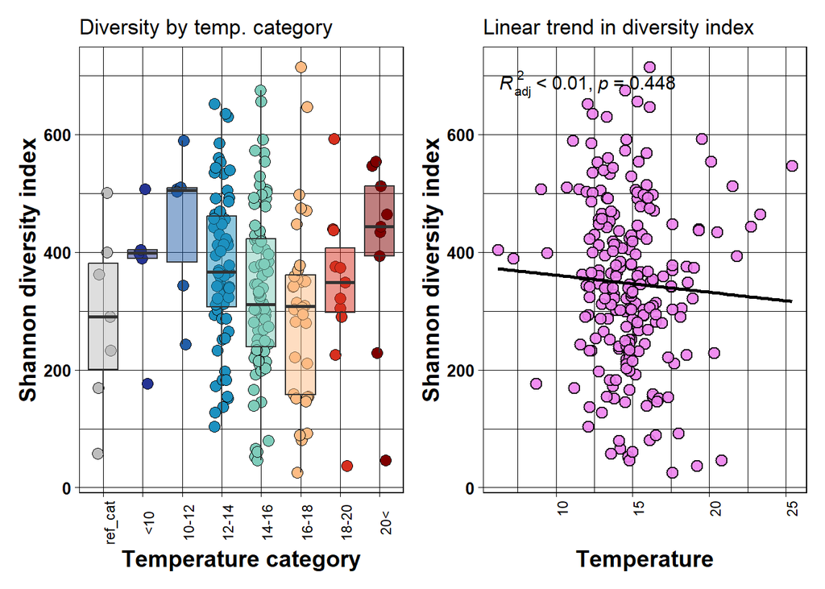

```r
p1_en_li <- cbind(as.data.frame(ens), metadata$Temp) %>%
  as.data.frame() %>%
  rename("div"= "ens","temp"="metadata$Temp") %>%
  filter(temp != "NA") %>%

# plot
  ggplot(aes(temp,div)) +
  geom_point(shape=21, size = 3, fill = "violet", alpha = 0.9, stroke = 0.6) +
  geom_smooth(method = "lm", se= FALSE, color = "black") +
  ggpmisc::stat_poly_eq(use_label(c("adj.R2", "p")),
                        label.y = "top", size = 4,
                        small.p = TRUE) +
  labs(y = "Shannon diversity index", x ="Temperature",
       title = "Linear trend in diversity index") +
  theme(legend.position = "none",
        axis.title=element_text(size=14,face="bold"),
        axis.text.y = element_text(size=10,face="bold"),
        axis.text.x = element_text(angle = 90))

p1_en + p1_en_li
```

## 3.2 Spatial distribution

Plot the diversity index on an interactive map to see if there is a geographical pattern to the alpha diversity.

```r
# add mapview to change X and Y to standard crs
new_metadata2 <- metadata %>%
  cbind(., as.data.frame(ens)) %>%
  filter(Temp != "NA") %>%
# add small value to coordinates for one of the campaigns
# so they do not overlap completely on the map
  mutate(X = ifelse(grepl("fall", sample_season) , X + 45, X)) %>%
  dplyr::select("ens", "X", "Y") %>%
  drop_na() %>%
  mutate( ens_cat = cut(ens, b=6) )


pal <-  mapviewPalette("mapviewSpectralColors")

sf_data <- st_as_sf(new_metadata2, coords = c("X", "Y"),  crs = 31253)
mapview(sf_data,  map.types = "Stamen.Terrain", col.regions = pal(10),
        zcol= "ens_cat", zoom = 12, color="black",
        cex = 5, alpha = 0.7 )
```

[interactive chart not shown]

Does not seem to be the case, since even the reference samples are not uniform in the color palette. The pattern also changes seasonally. There is no uniformity in higher diversity locations, neither the city center nor the outskirts are predominately diverse/low in diversity.

## 3.3 Aquifer distributuion

We chose all the aquifers that had more than 5 sampling points to see whether there is an impact of aquifer categorisation on the diversity index.

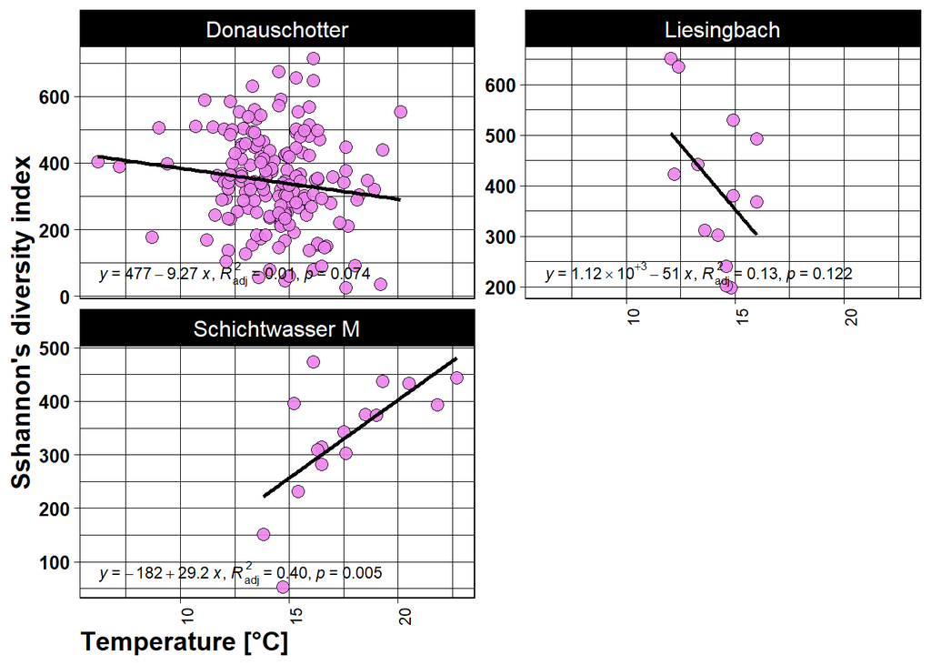

```r
cbind( metadata, ens ) %>%
# filter out aquifers that have less than 5 sample points
  dplyr::filter(! Geol_beb %in%  c("n.b.", "lokaler Aquifer",
                                   "Wiental", "Zubringer", "OF")) %>%
# do not differentiate between the different Donauschotter samples
                mutate(Geol_beb = case_when(
                            grepl('DS', Geol_beb) ~ "Donauschotter",
                                              TRUE ~ Geol_beb)) %>%
  dplyr::select("ens", "Geol_beb", "Temp") %>%
  na.omit() %>%
# plot
  ggplot(aes(x=Temp, y=ens)) +
  geom_point(shape=21, size = 3, fill = "violet", alpha = 0.9, stroke = 0.5) +
  geom_smooth(method = "lm", se= FALSE, color = "black") +
  facet_wrap(~ Geol_beb, scales = "free_y", ncol = 2) +
  stat_poly_eq(use_label(c("eq", "adj.R2", "p")),
               label.y = "bottom", small.p = TRUE,
               size = 3) +
  labs(x = "Temperature [°C]",
       y = "Sshannon's diversity index") +
  theme(axis.title.x = element_text(hjust = 0),
        legend.position = "none",
        axis.title=element_text(size=14,face="bold"),
        axis.text.y = element_text(size=10,face="bold"),
        axis.text.x = element_text(angle = 90),
        strip.text = element_text(size = 12))
```

All three aquifer types have a different range of temperature. Donauschotter with the most sampling points and the widest area, spans across the 5-20 °C, while Liesingbach falls in the medium temperature range, and Schichtwasser on the warmer side of the spectrum.

While Schichtwasser groundwater exhibits the clearest trend, increasing (p<0.05), with a linear regression explaining 40% of the variation, it is unclear whether model is sensical from the biology point of view - it is questionable whether Schichtwasser can be regarded as an uniform aquifer categorization considering that individual ground wells within this category are wildly heterogenous.

## 3.4 Modelling

Considering that there is no clear impact of temperature, aquifer nor location on the diversity distribution, we look into what environmental variables significantly impact alpha diversity:

```r
df_alpha <- metadata %>%
  cbind(as.data.frame(ens)) %>%
  dplyr::select(where(is.numeric)) %>%
  dplyr::select(-c("NH4", # many NAs
            "X", "Y")) %>% # coordinates
  na.omit() %>%
  scale(center = T, scale = T) %>%
  as.data.frame()


# remove the highly correlated ones
cor_matrix <- cor(df_alpha)
highly_correlated <- caret::findCorrelation(cor_matrix, cutoff = 0.9)
df_alpha <- df_alpha[, -highly_correlated]

# run individual regressions for each variable
varlist <- names(df_alpha)[-19]
models <- lapply(varlist, function(x) {
    form <- formula(paste("ens ~", x))
    lm(form, data=df_alpha)
})
# tidy up the results
lapply(models, function(x) tidy(x)) %>% bind_rows() -> ind_models
ind_models %>% filter(term != "(Intercept)") %>% filter(p.value<0.05)
```

```
## # A tibble: 0 × 5
## # ℹ 5 variables: term <chr>, estimate <dbl>, std.error <dbl>, statistic <dbl>, p.value <dbl>
```

```r
# none are sign
```

No variables have a significant individual effect on the Shannon’s diversity index.

Let’s see if there is a better fit of multiple regression of numeric variables:

```r
fullModel = lm(ens ~ ., data=df_alpha) # model with all  variables

# remove high vif variables
car::vif(fullModel)  %>% as.data.frame() %>%
  dplyr::rename("vif"=".") %>%
  filter(vif<10)  %>%
  rownames_to_column("envs") %>%
  dplyr::select("envs")  -> colnames

df_alpha2 <- df_alpha %>% dplyr::select("ens",
                                       which(colnames(df_alpha) %in% colnames$envs ))

fullModel = lm(ens ~ .  , data = df_alpha2) # model with all  variables


#choose
step.model<- MASS::stepAIC(fullModel, # start with a model containing no variables
                    direction = 'both', # run forward selection
                    trace = 0) # dont show step-by-step process of model selection

#summary(step.model) # none
RsquareAdj(step.model) # <2%
```

```
## $r.squared
## [1] 0.01924285
##
## $adj.r.squared
## [1] 0.008973141
```

There is still no significant effect, even a combined one. Next step would be to go beyond the analysis by numeric and categorical variables (aquifer categorization), respectively, and try to go for an interplay of both categorical and numeric variables. To be done later.

# 4 Composition

The taxonomic composition by temeprature categories was done in form of barplot and bubble plot, and defined numerically.

No immediate difference can be seen. Nanoarchaea visibly the most abundant clalss in each category.

## 4.1 Bar plot

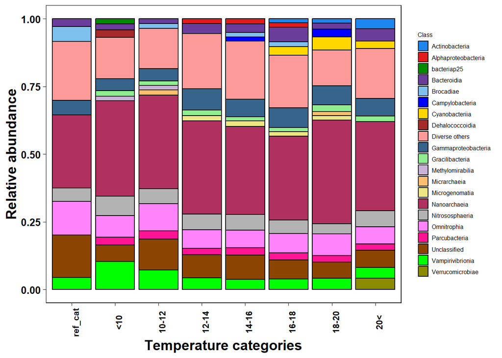

```r
# detach(package:plyr, unload = TRUE)
# tried fixing conflicts from select and filter by detaching
# but it is a conflict with some other package as well
# simply continue adding dplyr:: before the command

asv_table %>%
  mutate_if(is.integer, as.numeric) %>%
  mutate(class = tax_table$Class) %>%
  pivot_longer(cols = -class, values_to = "abundance", names_to = "sample") %>%
  left_join(.,metadata, by = c("sample" = "sample_season")) %>%
  dplyr::select ("abundance", "class", "category") %>%
# to remove those with no category
  dplyr::filter(category != "NA") %>%
# to make NA classes Unclassified
  replace_na(list(class ='Unclassified' )) %>%
  mutate(category = as.factor(category),
         class = as.factor(class)) %>%
# to find relative abundance within each category
  dplyr::group_by(category) %>%
  mutate (rel_abund = abundance / sum(abundance)) %>%
  ungroup() %>%
# to sum up all the counts of one class from all the samples
  dplyr::group_by(category, class) %>%
  summarise(rel_abund = sum(rel_abund)) %>%
  ungroup() %>%
# those very rare categorize as Diverse others
  dplyr::group_by(category, class) %>%
  mutate(class = case_when(rel_abund< 0.015~ "Diverse others",
                           TRUE ~ class)) %>%
  ungroup() %>%
# final regrouping after categorizing for Diverse others
  dplyr::group_by(category, class) %>%
  summarise(rel_abund = sum(rel_abund)) %>%
  ungroup() %>%

# plot
  ggplot(aes(x = category, y = rel_abund, fill = class)) +
  geom_bar(stat = "identity", color = "black") +
  scale_fill_manual(values=c25) +
  theme(panel.grid = element_blank(), legend.position="right",
        legend.text = element_text(size = 6),      # Adjust the text size
        legend.title = element_text(size = 6),
        legend.key.size = unit(0.4, "cm"),
        axis.title=element_text(size=14,face="bold"),
        axis.text.y = element_text(size=10,face="bold"),
        axis.text.x = element_text(angle = 90, face = "bold")) +
  labs(x = "Temperature categories",
       y = "Relative abundance",
       fill = "Class") +
  guides(fill=guide_legend(ncol = 1)) +
  scale_x_discrete(limits = name_vector)
```

## 4.2 Bubble plot

The same analysis,but with an alternative visualization is done by a bubble plot, where each phylogenetic group is more easily comparable across the categories.

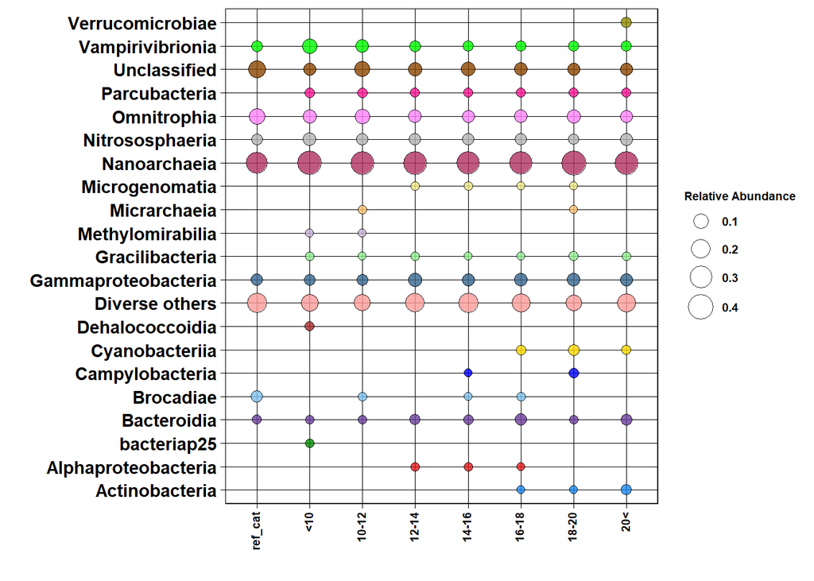

```r
asv_table %>%
  mutate_if(is.integer, as.numeric) %>%
  mutate(class = tax_table$Class) %>%
  pivot_longer(cols = -class, values_to = "abundance", names_to = "sample") %>%
  left_join(.,metadata, by = c("sample" = "sample_season")) %>%
  dplyr::select ("abundance", "class", "category") %>%
# to remove those with no category
  dplyr::filter(category != "NA") %>%
# to make NA classes Unclassified
  replace_na(list(class ='Unclassified' )) %>%
  mutate(category = as.factor(category),
         class = as.factor(class)) %>%
# to find relative abundance within each category
  dplyr::group_by(category) %>%
  mutate (rel_abund = abundance / sum(abundance)) %>%
  ungroup() %>%
# to sum up all the counts of one class from all the samples
  dplyr::group_by(category, class) %>%
  summarise(rel_abund = sum(rel_abund)) %>%
  ungroup() %>%
# those very rare categorize as Diverse others
  dplyr::group_by(category, class) %>%
  mutate(class = case_when(rel_abund< 0.015~ "Diverse others",
                           TRUE ~ class)) %>%
  ungroup() %>%
# final regrouping after categorizing for Diverse others
  dplyr::group_by(category, class) %>%
  summarise(rel_abund = sum(rel_abund)) %>%
  ungroup() -> data

# plot
data %>%
  ggplot(aes(x = as.factor(category), y = as.factor(class) )) +
  geom_point(aes(size = rel_abund, fill=class ),
             alpha = 0.8, shape = 21, stroke = 0.5) +
  scale_size_continuous(limits = c(0.001, 0.4), range = c(1,7)) +
  labs( x= "", y = "", size = "Relative Abundance", fill = "")  +
  theme(legend.key=element_blank(),
        axis.text.x = element_text(colour = "black", size = 7, face = "bold",
                                   angle = 90, vjust = 0.3, hjust = 1),
        axis.text.y = element_text(colour = "black", face = "bold", size = 11),
        legend.text = element_text(size = 7, face ="bold", colour ="black"),
        legend.title = element_text(size = 7, face = "bold"),
        legend.position = "right") +
  scale_fill_manual(values = c25, guide = "none") +
  scale_y_discrete(limits = rev(levels(data$class))) +
  scale_x_discrete(limits = name_vector)
```

For all categories, the most prevailing class was Nanoarchaeia, from the Archaea domain (33.3% ± 3.34% across all categories). The most abundant class from the Bacteria domain was Omnitrophia (8.19% ± 2.13%), and the fourth most abundant class overall also belonged to the Archaea domain - Nitrososphaeria (5.44% ± 1%). From the phylum Proteobacteria, the most abundant class was Gammaproteobacteria (6.2% ± 1.28%).

```r
# i usually do it with phyloseq:
# ps_for_sd <- tax_glom(ps_all, "Class") %>%
# transform_sample_counts(., function(x) x/sum(x))
# tb <- psmelt(ps_for_sd) %>%  as_tibble
# tb0 <- tb %>%
#  group_by(Class) %>%
#  dplyr::summarize( Mean = mean(abund), SD = sd(abund) ) %>%
#  ungroup() %>%
#  mutate( Mean_per = .$Mean *100, sd_per = .$SD *100 )  %>%
#  dplyr::filter( Mean_per > 1 ) %>%
#  left_join(.,
#            distinct( tax_table[, c("Kingdom", "Phylum", "Class")], Class ,
#                      .keep_all = TRUE ) ,
#            by="Class")

# head(tb0[order(tb0$Mean_per), c("Class", "Mean_per", "sd_per", "Phylum")])
# head(tb0[, c("Class", "Kingdom", "Phylum")] )


# but this shows the relative abundance per sample
# it seems more sensible to have the following results with what is shown in plots:


data %>% # as summarized in the above chunk
  group_by(class) %>%
  summarise( Mean = mean(rel_abund), SD = sd(rel_abund) ) %>%
  ungroup() %>%
  dplyr::mutate( Mean_perc = .$Mean *100, sd_perc = .$SD *100)  %>%
  ungroup() %>%
  arrange(desc(Mean_perc) ) %>%
  dplyr::select(!c("Mean", "SD")) %>%
  dplyr::filter(Mean_perc > 2) %>%
  knitr::kable()
```

| class | Mean_perc | sd_perc |
| --- | --- | --- |
| Nanoarchaeia | 33.285301 | 3.3370773 |
| Diverse others | 18.123985 | 3.2817574 |
| Unclassified | 8.735224 | 3.3517488 |
| Omnitrophia | 8.186963 | 2.1253453 |
| Gammaproteobacteria | 6.200316 | 1.2829794 |
| Nitrososphaeria | 5.443765 | 0.9928902 |
| Vampirivibrionia | 5.266635 | 2.3651606 |
| Verrucomicrobiae | 4.105556 | NA |
| Cyanobacteriia | 3.569844 | 1.1011691 |
| Bacteroidia | 3.195048 | 1.2293461 |
| Brocadiae | 2.715390 | 1.8909469 |
| Dehalococcoidia | 2.680000 | NA |
| Parcubacteria | 2.641222 | 0.3079224 |
| Actinobacteria | 2.296654 | 1.2316400 |
| Campylobacteria | 2.189329 | 0.9343295 |

## 4.3 Mathano-gens/trophs

Considering the high methane concentrations in Vienna, we tried connecting the concentrations to the taxa which are known to be connected to the methane processes.

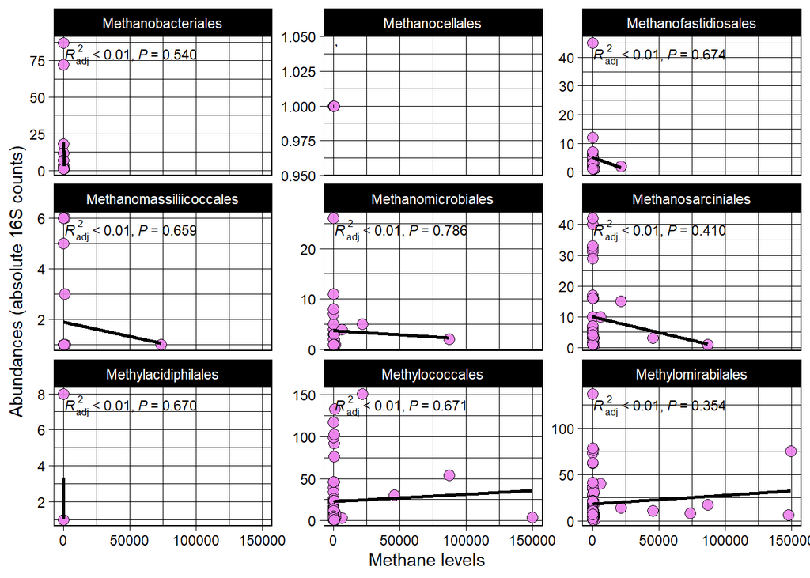

```r
# 1. clean taxonomy
# subset the "Methylo-" and "Methano-" taxa at the order level
tax_table %>% rownames_to_column("asv") %>%
# filter the methane taxa
dplyr::filter(grepl('Meth', Order)) %>%
dplyr::select("asv", "Order")  -> tax_meth


# 2. clean asv_table
# choose only the asvs from the selected orders
asv_table[which(rownames(asv_table) %in% tax_meth$asv ),] %>%

# only spring has CH4 measures, select spring samples
  rownames_to_column("asv") %>%
  pivot_longer(cols = -asv, names_to = "samples", values_to = "abundances") %>%

# filter only the spring samples
  dplyr::filter(grepl('spring', samples)) %>%

# connect to the order information
  left_join(., tax_meth, by = "asv") %>%
  dplyr::select("samples", "Order", "abundances") %>%
  group_by(samples, Order) %>%

# sum up the abundance within each order (diff sp/taxa)
  summarise(abund = sum(abundances)) %>%
  ungroup() %>%

# remove the samples where abundance is 0
  dplyr::filter(abund != "0") %>%

# connect the asv data to the metadata (methane level)
  left_join(., spring_data_additional[,c("sample_season", "CH4")],
            by = c("samples" = "sample_season") ) %>%

# remove the samples that do not have methane measures
 dplyr::filter(CH4 != "NA") %>%

# plot
ggplot(aes(x = CH4 , y = abund)) +
  geom_point(shape=21, size = 3, fill = "violet", alpha = 0.9, stroke = 0.5) +
  geom_smooth(method = "lm", se= FALSE, color = "black") +
  facet_wrap(~ Order, scales = "free_y") +
  stat_poly_eq(use_label(c( "adj.R2", "p")),
               label.y = "top",
               size = 3) +
  labs(y="Abundances (absolute 16S counts)",
       x= "Methane levels")
```

Although this line seemed promising, the dataset did not have many samples which were outside of the lines of eliminating cross-section (unknown CH4 levels, unclassified order, and/or 0 abundance in the sample). Taking that into account we can look closer into “Methylococcales”, “Methylomirabilales” and “Methanosarciniales”. However, even these three do not provide a robust correlation.

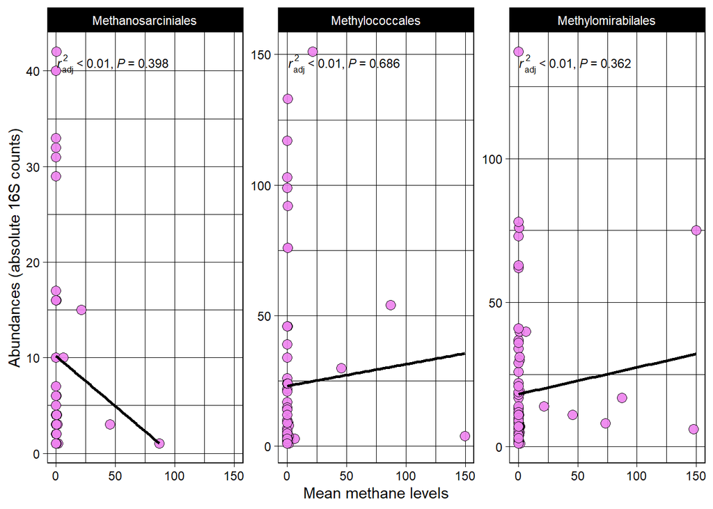

```r
# the same filtering as above
asv_table[which(rownames(asv_table) %in% tax_meth$asv ),] %>%
  rownames_to_column("asv") %>%
  pivot_longer(cols = -asv, names_to = "samples", values_to = "abundances") %>%
  dplyr::filter(grepl('spring', samples)) %>%
  left_join(., tax_meth, by = "asv") %>%
  dplyr::select("samples", "Order", "abundances") %>%
  group_by(samples, Order) %>%
  summarise(abund = sum(abundances)) %>%
  ungroup() %>%
  dplyr::filter(abund != "0") %>%

# but connect it to the sd_CH4, not CH4 in hopes of clearer trends
  left_join(., spring_data_additional[,c("sample_season", "Mean_CH4")],
            by = c("samples" = "sample_season") ) %>%
  dplyr::filter(Mean_CH4 != "NA") %>%

# filter the selected orders
  dplyr::filter(Order %in% c( "Methylococcales",
                              "Methylomirabilales",
                              "Methanosarciniales")) %>%

# plot
ggplot(aes(x = Mean_CH4 , y = abund)) +
  geom_point(shape=21, size = 3, fill = "violet", alpha = 0.9, stroke = 0.5) +
  geom_smooth(method = "lm", se= FALSE, color = "black") +
  facet_wrap(~ Order, scales = "free_y") +
  stat_poly_eq(use_label(c( "adj.R2", "p")),
               label.y = "top", small.r = TRUE,
               size = 3) +
  labs(y="Abundances (absolute 16S counts)",
       x= "Mean methane levels")
```

# 5 Temperature-related abundance trends

After looking at alpha diversity for the temperature categories, and compositional differences per temperature categories at class level, here there is more mining for trends at lower taxonomic levels.

Since there is a lot of unclassified ASVs on lower taxonomic levels, order was esteemed low enough without losing too much information.

## 5.1 Linear

Searching for the significant linear trend between abundances and temperature:

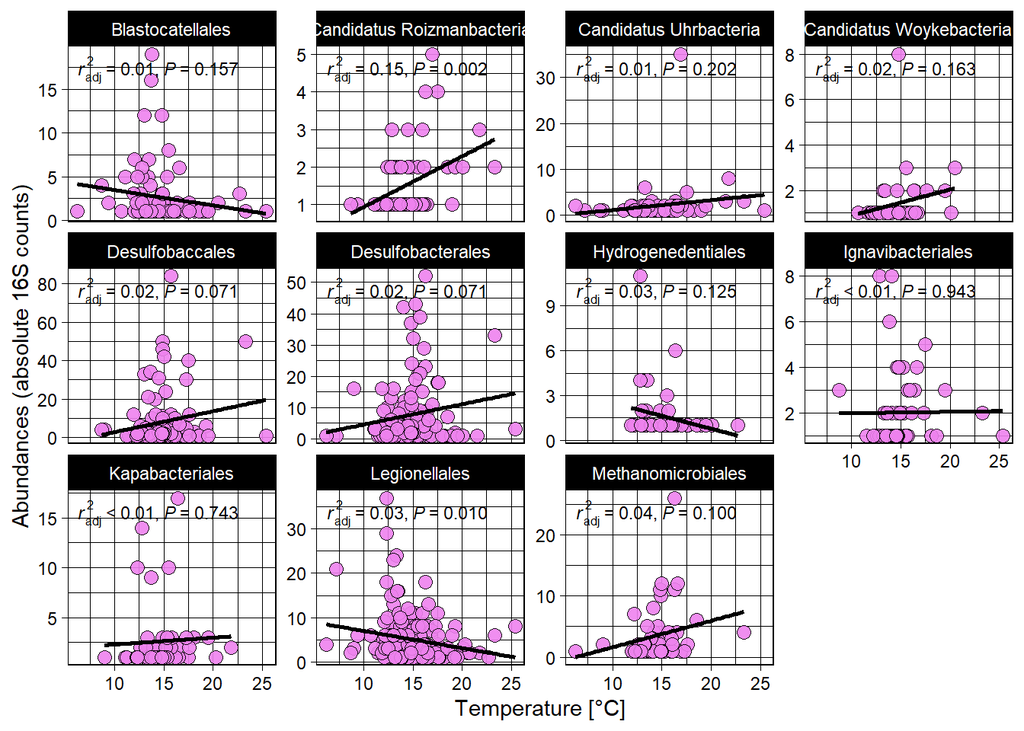

```r
# 1. clean taxonomy
tax_table %>% rownames_to_column("asv") %>%
dplyr::select("asv", "Order") %>%
# rename the unclassified taxa
replace_na(list(Order ='Unclassified' )) -> tax_order


# 2. manipulate data
asv_table %>%
  rownames_to_column("asv") %>%
  pivot_longer(cols = -asv, names_to = "samples", values_to = "abundances") %>%

# connect to the order information
  left_join(., tax_order, by = "asv") %>%
  dplyr::select("samples", "Order", "abundances") %>%
  group_by(samples, Order) %>%

# sum up the abundance within each order (diff sp/taxa)
  summarise(abund = sum(abundances)) %>%
  ungroup() %>%

# remove the samples where abundance is 0
  dplyr::filter(abund != "0") %>%

# connect the asv data to the metadata (temperature)
  left_join(., metadata[,c("sample_season", "Temp")],
            by = c("samples" = "sample_season") ) %>%

# remove the samples that do not have methane measures
 dplyr::filter(Temp != "NA") %>%

# filter only the orders which are present in 40+ samples
  group_by(Order) %>%
  mutate(n = n()) %>%
  ungroup() %>%
  dplyr::filter(n>40)  -> data_for_temp
# this is now 157 orders


# look at correlations btw order abundances and temperature
data_for_temp %>%
 group_by(Order) %>%
 cor_test(Temp, abund, method = "spearman") %>%
 ungroup() %>%
# choose only significant
 dplyr::filter(p<0.05) %>%
# remove unclassified
 dplyr::filter(Order != "Unclassified") %>%
 dplyr::select("Order")  -> corr_orders
#  this dataset now contains only the orders which exhibit sign corr.


data_for_temp [which(data_for_temp$Order %in% corr_orders$Order),
               c("Order", "abund",  "Temp")] %>%
# plot
ggplot(aes(x = Temp , y = abund)) +
  geom_point(shape=21, size = 3, fill = "violet", alpha = 0.9, stroke = 0.5) +
  geom_smooth(method = "lm", se= FALSE, color = "black") +
  facet_wrap(~ Order, scales = "free_y") +
  stat_poly_eq(use_label(c( "adj.R2", "p")),
               label.y = "top", small.r = TRUE,
               size = 3)+
  labs(y="Abundances (absolute 16S counts)",
       x= "Temperature [°C]")
```

Although there are certain significant correlations of order abundance and temperature, the results get less clear when the regression formula is used. This could be a result of non-parametric methods, like the correlation we used, being generally less affected by outliers.

The only order I would be comfortable claiming shows dependence would be the “Candidatus Roizmanbacteria”.

## 5.2 By category

We start with the 157 orders (selected orders that were found in 40+ samples), and their abundances and temperature measurements. Instead of using the otherwise present temperature categorization with 2 °C steps, new categorization was done with 0-13-15-15+ temperatures, since ~50% of data points is within the 13-16 range. This way the cold and warm extreme is on either side of the 13-16 spectrum.

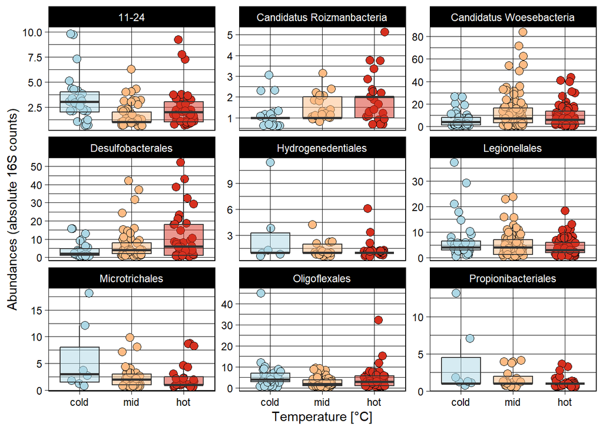

```r
# add >13-15< categorization
data_for_temp %>% dplyr::select(!c("n", "samples")) %>%
  mutate(temp_cat = case_when(Temp <13 ~ "cold",
                              Temp >15 ~ "hot",
                              Temp >= 13 & Temp <= 15 ~ "mid")) -> data_for_group


# look at anova btw order abundances and temperature groups
 data_for_group %>%
 group_by(Order) %>%
 anova_test(abund ~ temp_cat) %>%
 ungroup() %>%
 as.data.frame() %>%
# choose only significant
 dplyr::filter(p<0.05) %>%
 dplyr::select("Order")  -> corr_orders_group
#  this dataset now contains only the orders which exhibit sign diff.

data_for_group [which(data_for_group$Order %in% corr_orders_group$Order),
               c("Order", "abund",  "temp_cat")] %>%
# plot
ggplot(aes(x = temp_cat , y = abund)) +
  geom_jitter(width = 0.2, size = 3, shape=21, aes(fill = temp_cat) ) +
  geom_boxplot( alpha=0.5, outlier.shape = NA, aes(fill = temp_cat)) +
  facet_wrap(~ Order, scales = "free_y") +
  scale_x_discrete(limits = c("cold", "mid", "hot")) +
  scale_fill_manual(values = c("lightblue", "#d7301f", "#fdbb84")) +
  theme(legend.position = "none") +
  labs(y = "Abundances (absolute 16S counts)",
       x = "Temperature [°C]")
```

When looking at the groups there is still an upwards trend in the Candidatus Roizmanbacteria, but now there is also significant difference in the Desulfobacterales order. There is a downwards trend in Microtrichales, and Legionallales.

We can try to do a post-hoc test to see if it is significant.

```r
data_for_group %>%
 group_by(Order) %>%
 tukey_hsd(abund ~ temp_cat) %>%
 ungroup() %>%
 as.data.frame() %>%
# choose only significant
 dplyr::filter(p.adj.signif != "ns") %>%
 knitr::kable()
```

| Order | term | group1 | group2 | null.value | estimate | conf.low | conf.high | p.adj | p.adj.signif |
| --- | --- | --- | --- | --- | --- | --- | --- | --- | --- |
| 11-24 | temp_cat | cold | mid | 0 | -1.4450549 | -2.5335300 | -0.3565798 | 0.00588 | ** |
| Candidatus Roizmanbacteria | temp_cat | cold | hot | 0 | 0.7170868 | 0.0485569 | 1.3856167 | 0.03280 | * |
| Candidatus Woesebacteria | temp_cat | cold | mid | 0 | 7.3295344 | 1.1891257 | 13.4699430 | 0.01470 | * |
| Desulfobacterales | temp_cat | cold | hot | 0 | 6.7230769 | 0.8344027 | 12.6117511 | 0.02100 | * |
| Hydrogenedentiales | temp_cat | cold | hot | 0 | -1.8466667 | -3.6337782 | -0.0595552 | 0.04140 | * |
| Legionellales | temp_cat | cold | hot | 0 | -3.0772059 | -5.6542335 | -0.5001782 | 0.01460 | * |
| Microtrichales | temp_cat | cold | hot | 0 | -3.2484472 | -6.4135166 | -0.0833779 | 0.04300 | * |
| Microtrichales | temp_cat | cold | mid | 0 | -3.4025974 | -6.4537192 | -0.3514756 | 0.02530 | * |
| Oligoflexales | temp_cat | cold | mid | 0 | -2.9299896 | -5.4885644 | -0.3714147 | 0.02040 | * |
| Propionibacteriales | temp_cat | cold | hot | 0 | -2.3392857 | -4.3322896 | -0.3462819 | 0.01790 | * |

Desulfobacterales do indeed have a significantly different abundance between the cold and hot samples, as do the Candidatus Roizmanbacteria and Microtrichales.

# 6 Beta diversity

The rate of dissimilarity by temperature categories and aquifer type checked at genus level, which was deemed low enough taxonomy level, while not losing many unclassified species.

## 6.1 Temperature distribution

An nmds ordination is done with abundances summed at the genus level, and distances calculated, with a hellinger-transformed data, to account for the compositionality of data.

```r
# tax clean
tax_table %>% rownames_to_column("asv") -> tax_tab

# aggregate to genus level
asv_table %>%
  rownames_to_column("asv") %>%
  pivot_longer(cols = -asv, names_to = "samples",
               values_to = "abundances") %>%
  left_join(., tax_tab, by = "asv") %>%
  dplyr::select("samples", "Genus", "abundances") %>%
  group_by(samples,  Genus) %>%
  summarise(sum(abundances)) %>%
  ungroup() %>%
  replace_na(list(Genus ='Unclassified' )) %>%
  pivot_wider(names_from = "samples",
              values_from = "sum(abundances)") %>%
  column_to_rownames("Genus") -> asv_aggregated



# do an ordination with a hellinger transformation
sp.dist <-  vegdist(decostand( t(asv_aggregated),
                               method = "hellinger") )

# or without the transformation
# sp.dist <-  vegdist(t(asv_aggregated))
nmds <- metaMDS(sp.dist, k = 2, autotransform = FALSE)
```

Communities of high temperature samples are more dispersed (more dissimilar between themselves) than the cold and average-temperature samples.

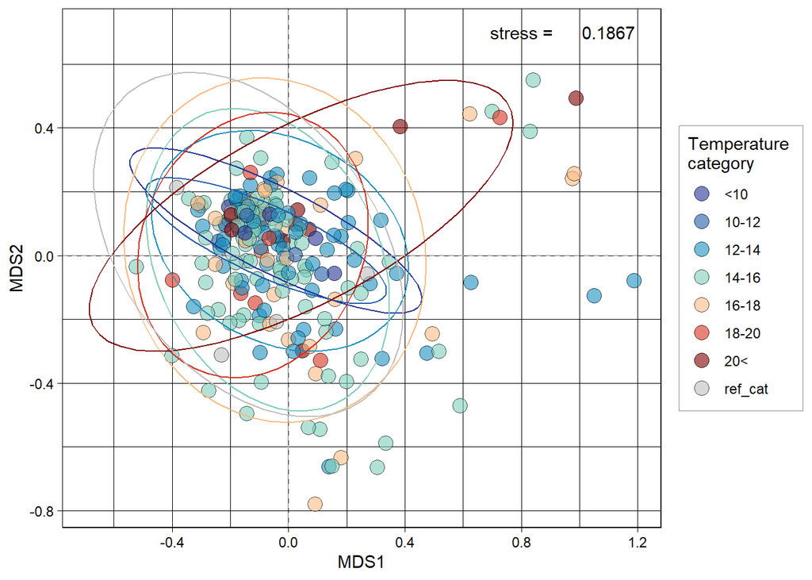

```r
# plot it
nmds_plot <- as.data.frame(nmds$points) %>%
  cbind(., as.factor(metadata$category)) %>%
  dplyr::rename("cat" = "as.factor(metadata$category)") %>%
  filter(cat !=  "NA") %>%
  ggplot(aes(x=MDS1,y=MDS2) ) +
  geom_point(aes( fill= cat), shape = 21,
             size = 4, alpha = 0.6, stroke = 0.5) +
# coloring
  scale_color_manual(values=pal3) +
  scale_fill_manual(values=pal3) +
# add stress value
  annotate(geom="text",x=0.8, y=0.7,
           label="stress =", color="black") +
  annotate(geom="text", x=1.1, y=0.7,
           label=round(nmds$stress,4), color="black") +
# ellipse
  stat_ellipse(aes(colour = cat), linewidth = 0.4) +
# visual parameters
  theme(legend.background = element_blank(),
        legend.box.background = element_rect(colour = "gray")) +
  labs(fill = "Temperature \ncategory") +
  guides(color = "none") +
  geom_vline(xintercept = c(0), color = "grey70", linetype = 2) +
  geom_hline(yintercept = c(0), color = "grey70", linetype = 2)

nmds_plot
```

Test whether there is significant differences between the communities of the different temperature categories:

```r
# 1. test dispersion as an assumption
# (variance test for multivariate statitics)
disp <- betadisper( sp.dist, metadata$category )

# p>0.05 is what we need - homogenous variances
anova(disp) # sign. differences in dispersion and we cant take sign, in centroids for granted
```

```
## Analysis of Variance Table
##
## Response: Distances
##            Df  Sum Sq   Mean Sq F value  Pr(>F)
## Groups      7 0.09873 0.0141050   2.222 0.03372 *
## Residuals 211 1.33939 0.0063478
## ---
## Signif. codes:  0 '***' 0.001 '**' 0.01 '*' 0.05 '.' 0.1 ' ' 1
```

```r
# 2. now test actual ordination
# test differences in group centroid with adonis
# (anova version for multivariate statistics)
permanova <- adonis2(sp.dist ~ metadata$category, na.action = na.omit,
                    method = "bray" , permutations = 999)
permanova # not sign.
```

```
## Permutation test for adonis under reduced model
## Terms added sequentially (first to last)
## Permutation: free
## Number of permutations: 999
##
## adonis2(formula = sp.dist ~ metadata$category, permutations = 999, method = "bray", na.action = na.omit)
##                    Df SumOfSqs      R2      F Pr(>F)
## metadata$category   7    0.911 0.03129 0.9737  0.539
## Residual          211   28.203 0.96871
## Total             218   29.114 1.00000
```

```r
# if it was significant i would test which groups are significantly different
#pair_res <- pairwiseAdonis::pairwise.adonis2(t(asv_aggregated) ~ category, data = new_metadata)
```

The temperature categories are not a sensical grouping for the microbial communities, as seen from the ordination plot and testing statistic.

## 6.2 Spatial distribution

The approach to checking whether geographical position impacts the microbial community adapted from: https://jkzorz.github.io/2019/07/09/scatter-plots.html

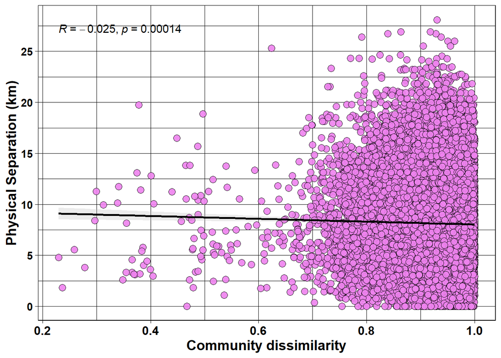

```r
# data with only the coordinates known
data_coo <- metadata %>%
      dplyr::select("sample_season", "X","Y") %>%
      na.omit()

gg <- data_coo %>%
      st_as_sf(., coords = c("X", "Y"), crs = 31253) %>%
      st_set_crs(31253) %>%
      st_transform(4326) %>%
      st_coordinates() %>%
      as.data.frame() %>%
      distm(., fun = distHaversine) %>%
      as.dist(.) %>% as.vector()

aa <- asv_table[, colnames(asv_table) %in% data_coo$sample_season] %>%
      t() %>%
      vegdist(., method = "bray") %>%
      as.vector()


matr <- data.frame(gg, aa)

ggplot(matr, aes(y = gg, x = aa)) +
  geom_point(size = 3, alpha = 0.9, color="black",
             shape = 21, fill= "violet",size = 5 ) +
  geom_smooth(method = "lm", colour = "black", alpha = 0.2) +
# add correlation info
  ggpubr::stat_cor(method = "spearman",
                   label.y.npc="top",
                   label.x.npc = "left",
                   color="black", size=4) +
# edit visualization
  labs(x = "Community dissimilarity",
       y = "Physical Separation (km)") +
  theme( axis.text.x = element_text(face = "bold",
                                    colour = "black", size = 12),
         axis.text.y = element_text(face = "bold",
                                    size = 11, colour = "black"),
         axis.title = element_text(face = "bold",
                                  size = 14, colour = "black")) +
# to turn y scale to kms
  scale_y_continuous(breaks = seq(0, 30000, by = 5000),
                     labels = function(x) x / 1000)
```

## 6.3 Aquifer distribution

Since the main focus of the study lies in temperature categories, we did not plot an ordination based on the aquifer type, but we tested to see whether it is an impactful factor.

```r
cbind(metadata, as.data.frame(nmds$points) ) %>%
dplyr::filter(! Geol_beb %in%  c("n.b.", "lokaler Aquifer",
                                   "Wiental", "Zubringer", "OF")) %>%
dplyr::select("Geol_beb") %>%
  na.omit() -> data_aq


# first test assumption: equal dispersion
disp_aq <- betadisper(
  vegdist(t(  asv_aggregated[,which(colnames(asv_aggregated) %in% rownames(data_aq))] ),
          method = "bray"),
          data_aq$Geol_beb )

#p>0.05 is what we need - homogenous variances
anova(disp_aq) #no sign. differences in dispersion
```

```
## Analysis of Variance Table
##
## Response: Distances
##            Df  Sum Sq  Mean Sq F value Pr(>F)
## Groups      4 0.05465 0.013662  1.1493 0.3346
## Residuals 197 2.34185 0.011888
```

```r
#TukeyHSD(disp) # if there was sign, i would check with this which one are they


# now test actual ordination
permanova_aq <- adonis2(t( asv_aggregated[,which(colnames(asv_aggregated) %in% rownames(data_aq))] ) ~
                        data_aq$Geol_beb,
                         method = "bray" ,
                        permutations = 999)
permanova # not sign
```

[output not shown]

# 7 Environmental data

To see whether there is certain patterns in the environmental variables, and which of them act in accordance to each other.

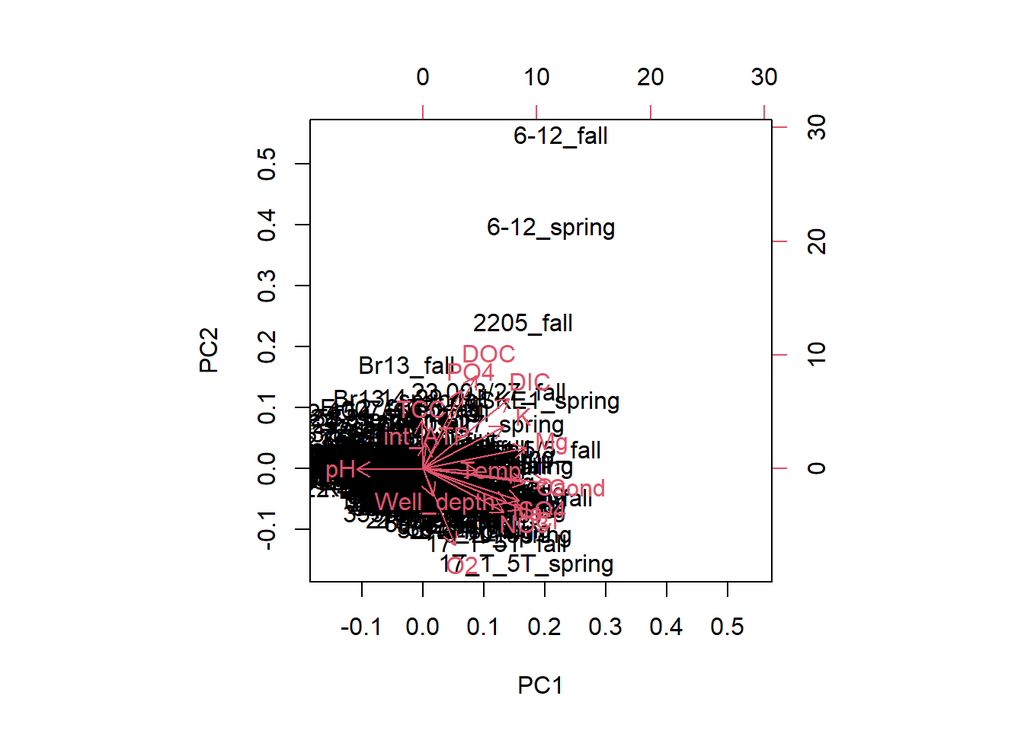

```r
# as done before:
df_alpha <- metadata %>%
  column_to_rownames("sample_season") %>%
  dplyr::select(where(is.numeric)) %>%
  dplyr::select(-c("NH4", # many NAs
            "X", "Y",     # coordinates
            "Extraction_depth", "Watercolumn", "GW_Table")) %>%
  na.omit() %>%
  scale(center = T, scale = T) %>%
  as.data.frame()
cor_matrix <- cor(df_alpha)
highly_correlated <- caret::findCorrelation(cor_matrix, cutoff = 0.9)
# none
# df_alpha <- df_alpha[, - highly_correlated]


# lets see if any env vars can be packed neatly in PCs
pca_env <- prcomp(df_alpha, scale = FALSE)
biplot(pca_env)
```

Both the fall and spring measurement of the 6-12 groundwater well jump out. Since they are outliers in both campaigns, we are inclined to believe it is not a sampling error. However, it is not easy to immediately see why this location would have such a heightened DOC.

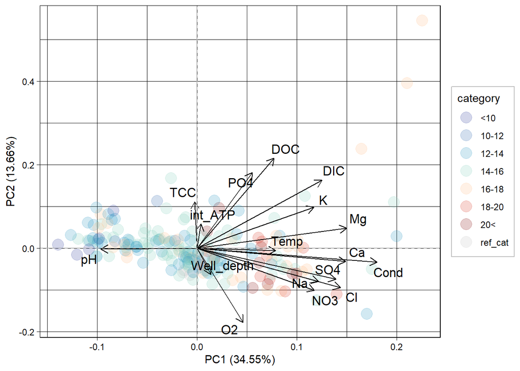

```r
ggplot2::autoplot(pca_env,

           data =
           (
           df_alpha %>%
           rownames_to_column("sample_season") %>%
           left_join(., metadata[,c("category", "sample_season")],
                     by = "sample_season")
           ),

         colour = 'category',
         size=5,
         alpha = 0.2,
         loadings = TRUE,
         loadings.colour = "black",
         loadings.label = TRUE,
         loadings.label.size = 4.3,
         loadings.label.colour = "black",
         loadings.label.repel = TRUE) +

  geom_vline(xintercept = c(0), color = "grey70", linetype = 2) +
  geom_hline(yintercept = c(0), color = "grey70", linetype = 2) +
  scale_color_manual(values = pal3)+
  theme(legend.background = element_blank(),
        legend.box.background = element_rect(colour = "gray"))  -> pca_plot


pca_plot
```

The first three principal components explain 57% of the environmental variance in data. High temperature samples vary in most of the measured variables, while the extremely cold samples mostly differ along the pH spectrum.

```r
summary(pca_env)$importance %>%
  as.data.frame() %>%
  dplyr::select("PC1", "PC2", "PC3", "PC4")
```

```
##                            PC1    PC2      PC3      PC4
## Standard deviation     2.42352 1.5239 1.252936 1.163263
## Proportion of Variance 0.34550 0.1366 0.092340 0.079600
## Cumulative Proportion  0.34550 0.4821 0.574450 0.654040
```

Let us see which variables vary together (i.e. which variables group together into a principal component):

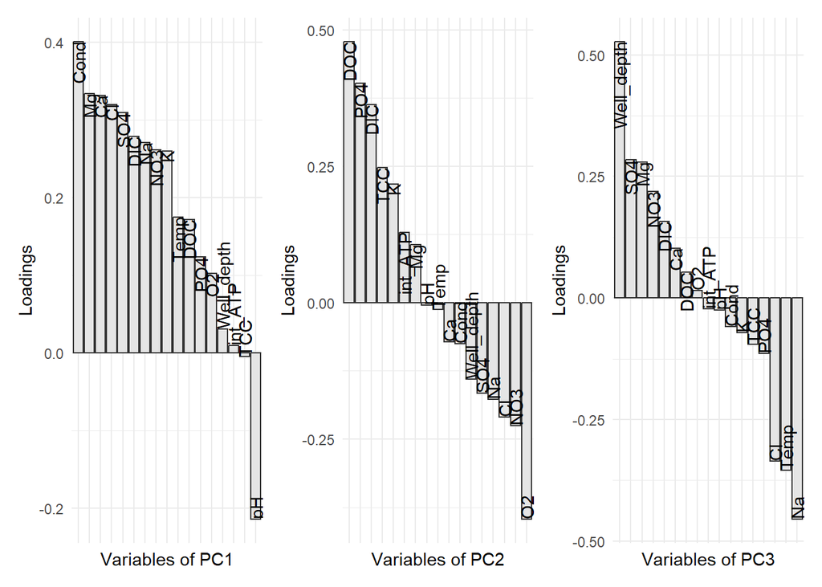

```r
# Extract the loadings from the PCA result and convert to tidy format
loadings_df <-   tidy(pca_env, matrix = "rotation")


# PC1
# Create the ggplot2 object for plotting the loadings
loadings_df %>% filter(PC == "1") %>%
  #x=reorder(class,-amount,sum)
ggplot( aes(x = reorder(column, -value), y = value, group = factor(column))) +
  geom_bar(stat = "identity", position = "dodge",
           fill= "gray90", color = "gray20") +
  geom_text(aes(label = column), position = position_dodge(width = 0.9),
            #vjust = "inward",
            angle = 90 , hjust = "inward") +
  labs(x = "Variables of PC1", y = "Loadings") +
  theme_minimal() +
  theme(axis.text.x = element_blank(),
        legend.position = "none")  -> plot_pca1

# PC2
loadings_df %>% filter(PC == "2") %>%
  #x=reorder(class,-amount,sum)
ggplot( aes(x = reorder(column, -value), y = value, group = factor(column))) +
  geom_bar(stat = "identity", position = "dodge",
           fill= "gray90", color = "gray20") +
  geom_text(aes(label = column), position = position_dodge(width = 0.9),
            #vjust = "inward",
            angle = 90 , hjust = "inward") +
  labs(x = "Variables of PC2", y = "Loadings") +
  theme_minimal() +
  theme(axis.text.x = element_blank(),
        legend.position = "none") -> plot_pca2

# PC3
loadings_df %>% filter(PC == "3") %>%
  #x=reorder(class,-amount,sum)
ggplot( aes(x = reorder(column, -value), y = value, group = factor(column))) +
  geom_bar(stat = "identity", position = "dodge",
           fill= "gray90", color = "gray20") +
  geom_text(aes(label = column), position = position_dodge(width = 0.9),
            #vjust = "inward",
            angle = 90 , hjust = "inward") +
  labs(x = "Variables of PC3", y = "Loadings") +
  theme_minimal() +
  theme(axis.text.x = element_blank(),
        legend.position = "none") -> plot_pca3

plot_pca1 + plot_pca2 + plot_pca3
```

The first PC mostly consist of variations in conductivity and mineral ions, as well as pH, which is why the cold samples fall away from the extremely hot ones along the x-axis.

The second PC consists of DOC, DIC and oxygen levels, as well as, to a certain extent, the PO4 and NO3 concentrations.

The third PC consists of the well depth variation.

To see how the environmental variables and their communities vary, we lay both ordinations side by side:

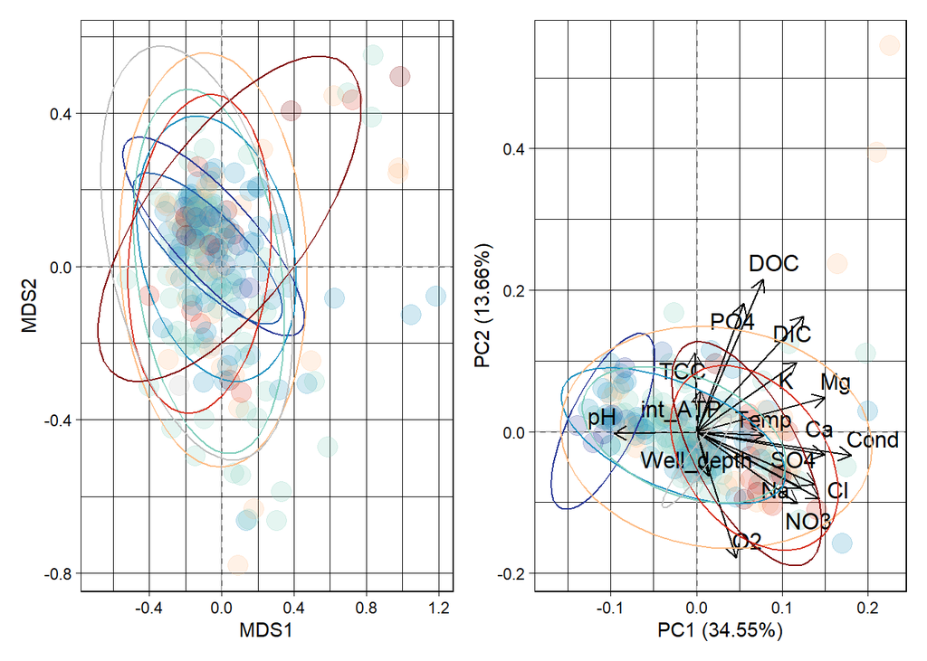

```r
nmds_plot2 <-  as.data.frame(nmds$points) %>%
  cbind(., as.factor(metadata$category)) %>%
  dplyr::rename("cat" = "as.factor(metadata$category)") %>%
  filter(cat !=  "NA") %>%
  ggplot(aes(x=MDS1,y=MDS2) ) +
  geom_point(aes( color = cat),
             size = 5, alpha = 0.2) +
  scale_color_manual(values=pal3) +
  stat_ellipse(aes(colour = cat), linewidth = 0.4) +
  theme(legend.position = "none") +
  geom_vline(xintercept = c(0), color = "grey70", linetype = 2) +
  geom_hline(yintercept = c(0), color = "grey70", linetype = 2)

pca_plot2 <- pca_plot + theme(legend.position = "none") +
  stat_ellipse(aes(colour = category), linewidth = 0.4)
nmds_plot2 + pca_plot2
```

Conclusion: there is no distinct clustering by temperature in terms of microbial communities, but the higher the temperature the bigger the dissimilarity/turnover of the sample communities.

It is possible that the low rate of environmental variation results in low dissimilarity (cold samples), and high variability results in high dissimilarity (warm samples). However, it is unexpected that such a stark difference in pH levels of the cold samples would not result in a high dissimilarity, since pH is known to be an important factor with microbial communities.

Worth noting is the high environmental homogeneity of the reference samples, which have, on the other hand, high turnover rates. A possible theory could be that biotic selection gains more importance in a stable environment, resulting with more stohastic final communties.

Since there is no clear relationships that confirm the importance of temperature for the composition, we continue with constrained ordination, and the search for envrionmental factors other than temperature that could be significant.

## 7.1 Constrained ordination

We use the CAP ordination as an distance-based alternative to the RDA (which uses bray, as opposed to RDA’s euclidean). Hellinger transformation (square root of relative abundances) is used to account for compositionality of data.

```r
# env clean
# df_alpha - already scaled and selected the important variables

# aggregate to genus
# asv_aggregated - already done for nmds

# asv clean
# because some samples get removed because of NAs
asv_aggregated [, which  ( colnames(asv_aggregated) %in% rownames(df_alpha)) ] -> sp.dat

# transform hellinger (or clr sometimes)
decostand(sp.dat, method = "hellinger") -> sp.dat
#clr(sp.dat) -> sp.dat

# 1. first model
simpleRDA <- capscale(t(sp.dat) ~  ., data = df_alpha ,
                 distance = "bray",
                 scaling = "sites")
# take only that are vif<10
env_vars_low_vif <- vif.cca(simpleRDA) %>%
                    as.data.frame() %>%
                    dplyr::rename("env" = ".") %>%
                    dplyr::filter(env < 10)

# make new environmental data with only low vif variables
df_alpha[,which(colnames(df_alpha) %in%  rownames(env_vars_low_vif) )] -> env.dat


# 2. model without them
simpleRDA <- capscale(t(sp.dat) ~  .,
                      data=  env.dat ,
                 distance = "bray",
                 scaling = "sites")


# test all variables and axes
# canonical axes
anova.model <- anova.cca(simpleRDA, by='axis', step=1000)
# no axes sign

# the whole model
anova.model2 <- anova.cca(simpleRDA, step=1000) #is sign
RsquareAdj(simpleRDA)$adj.r.squared # and explains <1%
```

```
## [1] 0.002119407
```

```r
# env parameters
anova.model3 <- anova(simpleRDA, step=1000, by = "term")
# none sign
```

None of the environmental variables are significant for the composition.

# 8 Donauschotter subset

Since possible impact of the aquifer type was discussed as a confounding variable, a subset that belongs to just one aquifer type was selected. It is the Donauschotter aquifer which spans over a big portion of Vienna and has the biggest portion of sampling points.

## 8.1 Data preparation

For the spring campaign, additional categorizations and measurements were performed, so the subset is not only constrained to the DS aquifer type, but also to the spring samples.

There is now the information on the waste water impact, redox phase and heat source effect for each sample, as well as heavy metal measurements.

```r
# already added the needed data in load data chunk

# I see that there is one duplicated sample,
# instead of going back to the data cleaning script I will remove it here
spring_data_additional <- spring_data_additional[ !duplicated(spring_data_additional$sample_season) ,]
# the step before added indexed rownames - remove them
rownames(spring_data_additional) <- c()

spring_data_additional %>%
  column_to_rownames("sample_season") %>%
  mutate(OF_beb = as.factor(OF_beb),
         Redox_beb = as.factor(Redox_beb),
         wastew_beb = as.factor(wastew_beb),
         hts_GWWP = as.factor(hts_GWWP),
         hts_EWS = as.factor(hts_EWS),
         hts_No_UHI = as.factor(hts_No_UHI),
         hts_UB = as.factor(hts_UB),
         hts_kanal = as.factor(hts_kanal),
         hts_FW = as.factor(hts_FW),
         hts_Altlast = as.factor(hts_Altlast),
         hts_OGFliess = as.factor(hts_OGFliess),
         hts_OGSteh = as.factor(hts_OGSteh),
         hts_Versie = as.factor(hts_Versie),
         hts_UHI = as.factor(hts_UHI),
         hts_count = as.factor(hts_count)) -> spring_data_additional


# add shannon diversity data
merge(as.data.frame(ens), spring_data_additional,
      by = "row.names")  -> spring_data_additional

# filter only DS subset
spring_data_additional %>%
  dplyr::filter(grepl('DS', Geol_beb)) %>%
  column_to_rownames("Row.names") -> spring_data_additional
```

## 8.2 Diversity in relation to env. variables

The distribution of alpha diversity by categories of: surface water impact, redox cascade phase and wastewater impact.

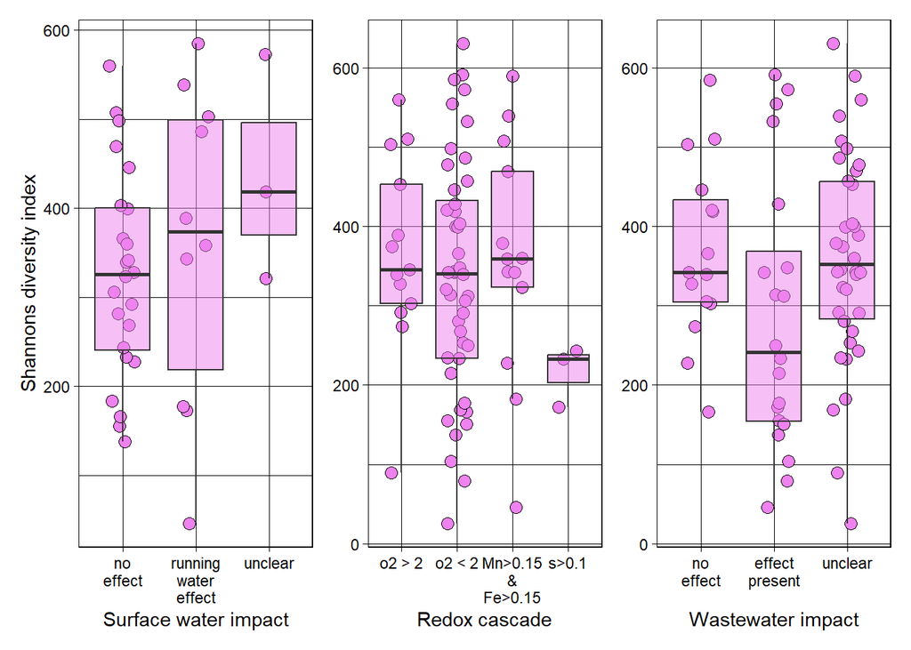

```r
# of_beb
split_labels <- str_wrap(c("no effect",            # for "1"
                           "running water effect", # for "2"
                           "unclear"),             # for "3"
                         width = 8)

p1 <- spring_data_additional %>%
  dplyr::filter(OF_beb != "NA") %>%
  ggplot(aes(x=OF_beb, y=ens)) +
  geom_jitter(width = 0.2, size = 3, shape=21, fill = "violet") +
  geom_boxplot(fill = "violet", alpha=0.5, outlier.shape = NA) +
  labs(x="Surface water impact",
       y= "Shannons diversity index") +
  scale_x_discrete(labels = split_labels)


# redox  (Redox_beb)
split_labels <- str_wrap(c("o2 > 2", "o2 < 2",
                           "Mn>0.15 & Fe>0.15",
                           "s>0.1"), width = 8)

p2 <- spring_data_additional %>%
  #dplyr::filter(OF_beb != "NA") %>%
  ggplot(aes(x=Redox_beb, y=ens)) +
  geom_jitter(width = 0.2, size = 3, shape=21, fill = "violet") +
  geom_boxplot(fill = "violet", alpha=0.5, outlier.shape = NA) +
  labs(x="Redox cascade",
       y= NULL) +
  scale_x_discrete(labels = split_labels)


# wastewater  (wastew_beb)
split_labels <- str_wrap(c("no effect",            # for "1"
                           "effect present", # for "2"
                           "unclear"), width = 8)

p3 <- spring_data_additional %>%
  #dplyr::filter(OF_beb != "NA") %>%
  ggplot(aes(x=wastew_beb, y=ens)) +
  geom_jitter(width = 0.2, size = 3, shape=21, fill = "violet") +
  geom_boxplot(fill = "violet", alpha=0.5, outlier.shape = NA) +
  labs(x="Wastewater impact",
       y= NULL) +
  scale_x_discrete(labels = split_labels)

p1 + p2 + p3
```

There is certain inclinations that waste water presence impact the diversity negatively, but significance is yet to be checked.

## 8.3 Diversity in relation to heat islands

Each sample has been catogorized in relation to a number of heat sources. For us the most interesting ones have been the surface sealing, due to its proven impact on groundwater temperatures, and the number of different heat sources that impact each sample.

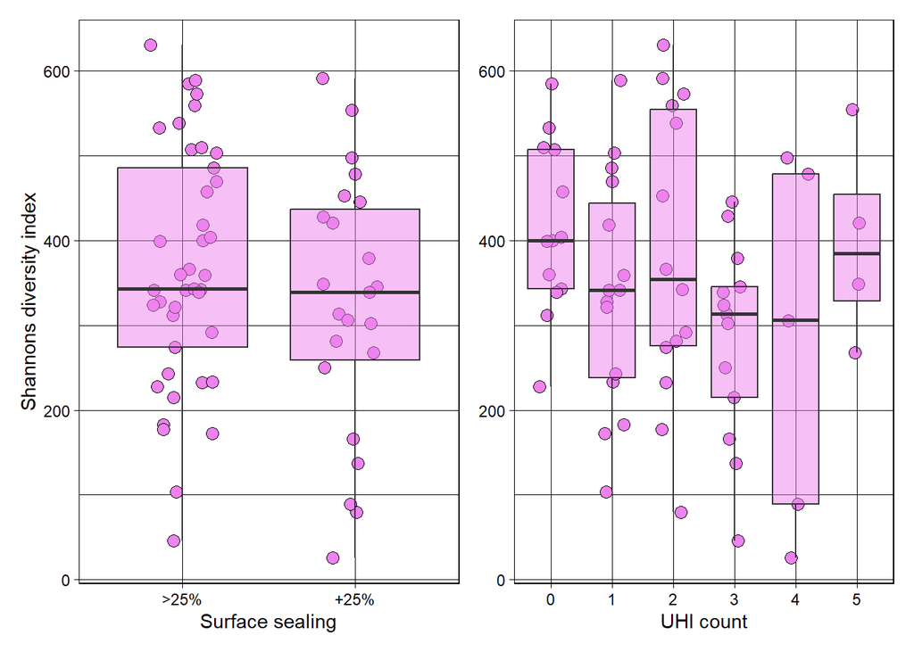

```r
# surface sealing
p4 <- spring_data_additional %>%
  dplyr::filter(hts_Versie != "NA") %>%
  ggplot(aes(x=hts_Versie, y=ens)) +
  geom_jitter(width = 0.2, size = 3, shape=21, fill = "violet") +
  geom_boxplot(fill = "violet", alpha=0.5, outlier.shape = NA) +
  labs(x="Surface sealing",
       y= "Shannons diversity index") +
 scale_x_discrete(labels = c(">25%", "+25%"))


# number of heat sources
p5 <- spring_data_additional %>%
  dplyr::filter(hts_UHI != "NA") %>%
  ggplot(aes(x=hts_UHI, y = ens)) +
  geom_jitter(width = 0.2, size = 3, shape=21, fill = "violet") +
  geom_boxplot(fill = "violet", alpha=0.5, outlier.shape = NA) +
  labs(x="UHI count",
       y= NULL)


p4 + p5
```

No clear difference in diversity based on the surface sealing. The median value of the Shannon’s diversity is the highest for the samples not impacted by a single heat source, significance yet to be checked.

## 8.4 Diversity in relation to metals

Now having the heavy metal data, see if there is impact of metals on the communties.

```r
spring_data_additional %>%
  dplyr::select("ens", "Al", "Cr", "Fe_57", "Ni", "Cu", "Zn",
                "As", "Ag", "Cd", "Hg", "Pb", "Mean_CO2", "Mean_CH4") %>%
  na.omit() %>%
  scale(center = T, scale = T) %>%
  as.data.frame() -> df_spring


# remove the highly correlated ones
cor_matrix <- cor(df_spring)
highly_correlated <- caret::findCorrelation(cor_matrix, cutoff = 0.9)
# no variables with coeff > 0.9

# run individual regressions for each variable
varlist <- names(df_spring)[- 1]
# remove ens, the independant var
models <- lapply(varlist, function(x) {
    form <- formula(paste("ens ~", x))
    lm(form, data=df_spring)
})
# tidy up the results
lapply(models, function(x) tidy(x)) %>% bind_rows() -> ind_models
ind_models %>% filter(term != "(Intercept)") %>% filter(p.value<0.05)
```

```
## # A tibble: 3 × 5
##   term     estimate std.error statistic p.value
##   <chr>       <dbl>     <dbl>     <dbl>   <dbl>
## 1 Ni          0.267     0.120      2.24  0.0287
## 2 Ag         -0.273     0.119     -2.29  0.0255
## 3 Mean_CH4   -0.265     0.120     -2.22  0.0301
```

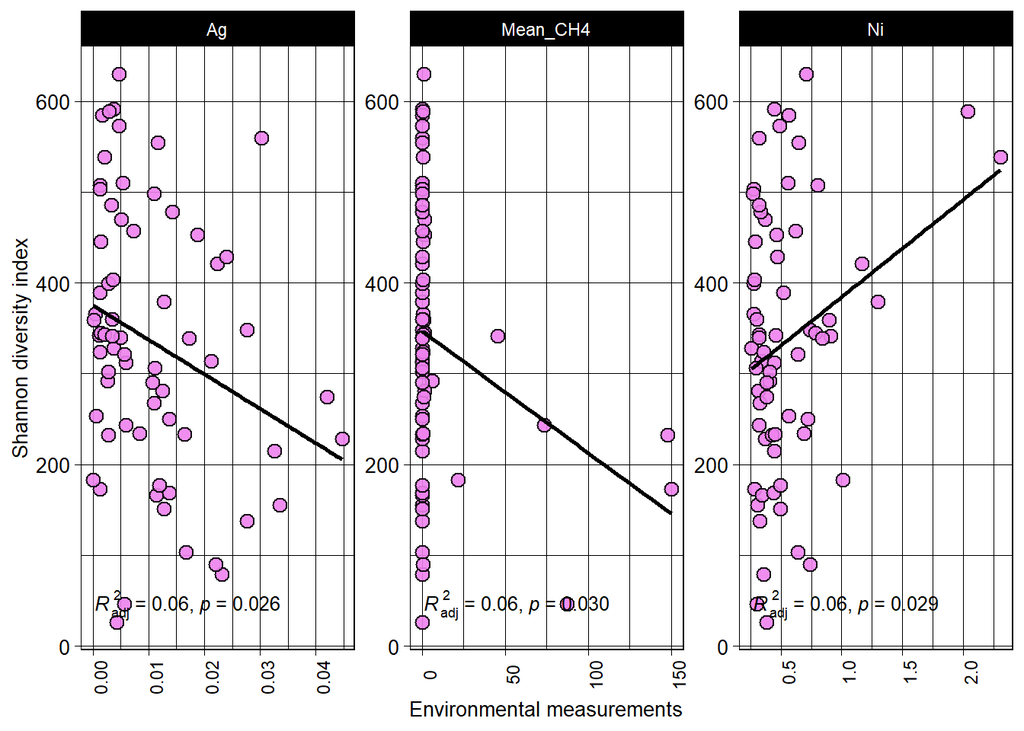

```r
spring_data_additional %>%
  dplyr::select("ens", "Ni", "Ag", "Mean_CH4") %>%
  na.omit() %>%
  pivot_longer(cols= -ens, values_to = "values",
               names_to = "vars") %>%
#plot

  ggplot(aes(y=ens, x=values)) +
  geom_point(shape=21, size = 3, fill = "violet",
             alpha = 0.9, stroke = 0.6) +
  geom_smooth(method = "lm", se= FALSE, color = "black") +
  ggpmisc::stat_poly_eq(use_label(c("adj.R2", "p")),
                        small.p = TRUE,
                        label.y = "bottom", size = 3.4) +
  facet_wrap(~vars, scales = "free") +
  labs(y = "Shannon diversity index",
       x ="Environmental measurements") +
  theme(legend.position = "none",
        axis.title = element_text(size=10),
        axis.text.y = element_text(size=10),
        axis.text.x = element_text(angle = 90))
```

Shannon’s diversity index shows significant regression to Ni, Ag and CH4, however the individual regressions do not provide satisfactory godness-of-fit, especially for the methane.

One final check with all the variables included and only the DS subset.

```r
spring_data_additional %>%
  dplyr::select(where(is.numeric)) %>%
   dplyr::select(-c("NH4", "S",      # many NAs
            "X", "Y",                # coordinates
            "N15_NO3", "O18_NO3",    # many NAs
            "CH4",                   # remove raw, keep sdCH4
            "d13_CO2")
            ) %>%
  na.omit() %>%
  scale(center = T, scale = T) %>%
  as.data.frame() -> df_spring_all


fullModel = lm(ens ~ ., data=df_spring_all) # model with all  variables

# remove high vif variables
car::vif(fullModel)  %>% as.data.frame() %>%
  dplyr::rename("vif"=".") %>%
  filter(vif<10)  %>%
  rownames_to_column("envs") %>%
  dplyr::select("envs")  -> colnames

df_spring_all2 <- df_spring_all %>% dplyr::select("ens",
                                       which(colnames(df_spring_all) %in% colnames$envs ))

fullModel = lm(ens ~ .  , data = df_spring_all2) # model with all  variables


#choose
step.model<- MASS::stepAIC(fullModel, # start with a model containing no variables
                    direction = 'both', # run forward selection
                    trace = 0) # dont show step-by-step process of model selection

# summary(step.model)
# none sign, but intATP borderline
RsquareAdj(step.model) # 7%
```

```
## $r.squared
## [1] 0.109026
##
## $adj.r.squared
## [1] 0.07338699
```

Adding metals and isolating the DS subset did not provide a satisfactory fit, even for the multiple regression.

## 8.5 Communities in relation to metals

Communities -> one final check with all the variables included and only the DS subset

```r
# env clean
# df_spring_all - already scaled and selected the important variables

# aggregate to genus
# asv_aggregated - already done for nmds

# asv clean
# because some samples get removed because of NAs
# and we need only the spring samples
asv_aggregated [, which  ( colnames(asv_aggregated) %in%
                             rownames(df_spring_all)) ] -> sp.dat

# transform hellinger (or clr sometimes)
decostand(sp.dat, method = "hellinger") -> sp.dat
#clr(sp.dat) -> sp.dat

# 1. first model
simpleRDA <- capscale(t(sp.dat) ~  ., data = df_spring_all ,
                 distance = "bray",
                 scaling = "sites")
# take only that are vif<10
env_vars_low_vif <- vif.cca(simpleRDA) %>%
                    as.data.frame() %>%
                    dplyr::rename("env" = ".") %>%
                    dplyr::filter(env < 10)

# make new environmental data with only low vif variables
df_spring_all[,which(colnames(df_spring_all) %in%
                       rownames(env_vars_low_vif) )] -> env.dat


# 2. model without them
simpleRDA <- capscale(t(sp.dat) ~  .,
                      data=  env.dat ,
                 distance = "bray",
                 scaling = "sites")


# test all variables and axes
# canonical axes
anova.model <- anova.cca(simpleRDA, by='axis', step=1000)
# no axes sign

# the whole model
anova.model2 <- anova.cca(simpleRDA, step=1000) #is sign
RsquareAdj(simpleRDA)$adj.r.squared # and explains <3%
```

```
## [1] 0.02819552
```

```r
# env parameters
anova.model3 <- anova(simpleRDA, step=1000, by = "term")
# none sign
anova.model3
```

```
## Permutation test for capscale under reduced model
## Terms added sequentially (first to last)
## Permutation: free
## Number of permutations: 999
##
## Model: capscale(formula = t(sp.dat) ~ ens + PO4 + Temp + O2 + int_ATP + Ni + Cu + Zn + Hg + GWM_Apr, data = env.dat, distance = "bray", scaling = "sites")
##          Df SumOfSqs      F Pr(>F)
## ens       1   0.4189 1.2303  0.107
## PO4       1   0.3464 1.0175  0.415
## Temp      1   0.4167 1.2240  0.112
## O2        1   0.4101 1.2046  0.118
## int_ATP   1   0.4029 1.1832  0.130
## Ni        1   0.3571 1.0488  0.333
## Cu        1   0.3387 0.9948  0.458
## Zn        1   0.4375 1.2851  0.073 .
## Hg        1   0.3540 1.0396  0.354
## GWM_Apr   1   0.4361 1.2808  0.062 .
## Residual 42  14.2999
## ---
## Signif. codes:  0 '***' 0.001 '**' 0.01 '*' 0.05 '.' 0.1 ' ' 1
```

This has not provided an impactful insight , either.

# 9 Conclusion

Few things we can claim with certainty are:

- there is some indication of decreasing Shannon diversity with increasing temperatures, although this is not supported by significance.
- the Schichtwasser aquifer shows an increase in diversity with a temperature increase (p<0.05)
- none of the measured variables are able to provide good fit for the diversity pattern
- the taxonomic composition of all temperature categories does not vary greatly, and in each it is Nanoarchaea that is dominant
- methane-processing microorganisms were not clearly correlated to the methane levels
- there is indication that *Candidatus Roizmanbacteria*, *Desulfobacterales*, *Microtrichales*, and *Legionallales* exhibit dependence with temperature, which is somewhat supported by significance
- there is no distinct clustering by temperature in terms of microbial communities, but the higher the temperature the bigger the dissimilarity/turnover of the sample communities
- there is indication that diversity is more impacted by the waste water and heavy metals (possible pollution), than temperature